# Divvy Case Study Full Year Analysis

MOHAMED M.

**Data Collection and Preparation:** The script starts by loading the necessary packages, such as tidyverse, lubridate, and ggplot2. The data https://divvy-tripdata.s3.amazonaws.com/index.html for Divvy bike sharing is loaded for each month over a one-year period, from May 2022 to April 2023, and stored into separate dataframes. This data is then checked for consistency in column names, and columns are renamed to ensure uniformity across all dataframes.

**Data Wrangling:** In the data wrangling phase, all the monthly dataframes are combined into a single dataframe called all_trips. Then, the latitude and longitude fields are removed as they are not needed for this analysis. A set of new columns are added which include the date, month, day, year, day of the week, and ride length for each ride.

*The primary goal of this script is to understand how members and casual riders use Divvy bikes differently. The script achieves this by cleaning and wrangling the data into a format that allows for this comparison, and then visualizing the results*.

```r
required_packages <- c("lubridate", "tidyverse", "ggplot2", "hms", "flexdashboard", "purrr", "readr")
for (package in required_packages) {
  if (!require(package, character.only = TRUE)) {
    install.packages(package)
    library(package, character.only = TRUE)
  }
}
```

Get a list of file names in the “data” directory. Read and combine all CSV files into a single dataframe

```r
file_list <- list.files("data/", pattern = "\\.csv$", full.names = TRUE)
all_trips <- bind_rows(lapply(file_list, read_csv))
```

### Data Wrangling:

```r
colnames(all_trips)
```

```
##  [1] "ride_id"            "rideable_type"      "started_at"
##  [4] "ended_at"           "start_station_name" "start_station_id"
##  [7] "end_station_name"   "end_station_id"     "start_lat"
## [10] "start_lng"          "end_lat"            "end_lng"
## [13] "member_casual"
```

Rename columns for better readability. Add columns for dates and time

```r
all_trips <- all_trips %>%
  rename(
    trip_id = ride_id,
    bikeid = rideable_type,
    start_time = started_at,
    end_time = ended_at,
    from_station_name = start_station_name,
    from_station_id = start_station_id,
    to_station_name = end_station_name,
    to_station_id = end_station_id,
    start_lat = start_lat,
    start_lng = start_lng,
    end_lat = end_lat,
    end_lng = end_lng,
    usertype = member_casual
  ) %>%
  mutate(
    date = as.Date(start_time),
    month = month(date),
    day = day(date),
    year = year(date),
    day_of_week = weekdays(date)
  )
```

### Data Cleaning:

Removing unused columns

```r
all_trips <- all_trips %>%
  select(-c(start_lat, start_lng, end_lat, end_lng))
```

```r
all_trips$start_time <- ymd_hms(all_trips$start_time)
all_trips$end_time <- ymd_hms(all_trips$end_time)
```

Inspect the new table that has been created

```r
colnames(all_trips)  #List of column names
```

```
##  [1] "trip_id"           "bikeid"            "start_time"
##  [4] "end_time"          "from_station_name" "from_station_id"
##  [7] "to_station_name"   "to_station_id"     "usertype"
## [10] "date"              "month"             "day"
## [13] "year"              "day_of_week"
```

```r
nrow(all_trips)  #How many rows are in data frame?
```

```
## [1] 5859061
```

```r
dim(all_trips)  #Dimensions of the data frame?
```

```
## [1] 5859061      14
```

```r
head(all_trips)  #See the first 6 rows of data frame.
```

| trip_id | bikeid | start_time | end_time | from_station_name | from_station_id | to_station_name | to_station_id | usertype | date | month | day | year | day_of_week |
| --- | --- | --- | --- | --- | --- | --- | --- | --- | --- | --- | --- | --- | --- |
| EC2DE40644C6B0F4 | classic_bike | 2022-05-23 23:06:58 | 2022-05-23 23:40:19 | Wabash Ave & Grand Ave | TA1307000117 | Halsted St & Roscoe St | TA1309000025 | member | 2022-05-23 | 5 | 23 | 2022 | Monday |
| 1C31AD03897EE385 | classic_bike | 2022-05-11 08:53:28 | 2022-05-11 09:31:22 | DuSable Lake Shore Dr & Monroe St | 13300 | Field Blvd & South Water St | 15534 | member | 2022-05-11 | 5 | 11 | 2022 | Wednesday |
| 1542FBEC830415CF | classic_bike | 2022-05-26 18:36:28 | 2022-05-26 18:58:18 | Clinton St & Madison St | TA1305000032 | Wood St & Milwaukee Ave | 13221 | member | 2022-05-26 | 5 | 26 | 2022 | Thursday |
| 6FF59852924528F8 | classic_bike | 2022-05-10 07:30:07 | 2022-05-10 07:38:49 | Clinton St & Madison St | TA1305000032 | Clark St & Randolph St | TA1305000030 | member | 2022-05-10 | 5 | 10 | 2022 | Tuesday |
| 483C52CAAE12E3AC | classic_bike | 2022-05-10 17:31:56 | 2022-05-10 17:36:57 | Clinton St & Madison St | TA1305000032 | Morgan St & Lake St | TA1306000015 | member | 2022-05-10 | 5 | 10 | 2022 | Tuesday |
| C0A3AA5A614DCE01 | classic_bike | 2022-05-04 14:48:55 | 2022-05-04 14:56:04 | Carpenter St & Huron St | 13196 | Sangamon St & Washington Blvd | 13409 | member | 2022-05-04 | 5 | 4 | 2022 | Wednesday |

```r
summary(all_trips)  #Statistical summary of data. Mainly for numerics
```

```
##    trip_id             bikeid            start_time
##  Length:5859061     Length:5859061     Min.   :2022-05-01 00:00:06.00
##  Class :character   Class :character   1st Qu.:2022-07-03 11:12:29.25
##  Mode  :character   Mode  :character   Median :2022-08-28 12:44:56.50
##                                        Mean   :2022-09-19 13:39:54.05
##                                        3rd Qu.:2022-11-08 06:30:15.00
##                                        Max.   :2023-04-30 23:59:05.00
##                                        NA's   :31
##     end_time                      from_station_name  from_station_id
##  Min.   :2022-05-01 00:05:17.00   Length:5859061     Length:5859061
##  1st Qu.:2022-07-03 11:38:52.00   Class :character   Class :character
##  Median :2022-08-28 13:07:18.00   Mode  :character   Mode  :character
##  Mean   :2022-09-19 13:59:04.64
##  3rd Qu.:2022-11-08 06:44:06.25
##  Max.   :2023-05-03 10:37:12.00
##  NA's   :23
##  to_station_name    to_station_id        usertype              date
##  Length:5859061     Length:5859061     Length:5859061     Min.   :2022-05-01
##  Class :character   Class :character   Class :character   1st Qu.:2022-07-03
##  Mode  :character   Mode  :character   Mode  :character   Median :2022-08-28
##                                                           Mean   :2022-09-18
##                                                           3rd Qu.:2022-11-08
##                                                           Max.   :2023-04-30
##
##      month             day             year      day_of_week
##  Min.   : 1.000   Min.   : 1.00   Min.   :2022   Length:5859061
##  1st Qu.: 5.000   1st Qu.: 8.00   1st Qu.:2022   Class :character
##  Median : 7.000   Median :15.00   Median :2022   Mode  :character
##  Mean   : 6.945   Mean   :15.67   Mean   :2022
##  3rd Qu.: 9.000   3rd Qu.:23.00   3rd Qu.:2022
##  Max.   :12.000   Max.   :31.00   Max.   :2023
##
```

Adding the ride length column

```r
all_trips$ride_length <- difftime(all_trips$end_time,all_trips$start_time)
```

```r
is.factor(all_trips$ride_length)
```

```
## [1] FALSE
```

```r
all_trips$ride_length <- as.numeric(as.character(all_trips$ride_length))
is.numeric(all_trips$ride_length)
```

```
## [1] TRUE
```

Removing negative ride_length values, creating a new version of the dataframe (v2) since data is being removed

```r
all_trips_v2 <- all_trips[!(all_trips$ride_length < 0),]
```

```r
all_trips_v2 <- all_trips_v2 %>%
  filter(ride_length >= 1 & ride_length <= 60 * 24)
```

```r
all_trips_v2$ride_length <- round(all_trips_v2$ride_length / 60, 2)
```

### Descriptive Analysis and Data Visualization::

Ride Length Analysis

```r
summary(all_trips_v2$ride_length)
```

```
##    Min. 1st Qu.  Median    Mean 3rd Qu.    Max.
##   0.020   5.050   8.430   9.543  13.280  24.000
```

Boxplot of ride length by user type:

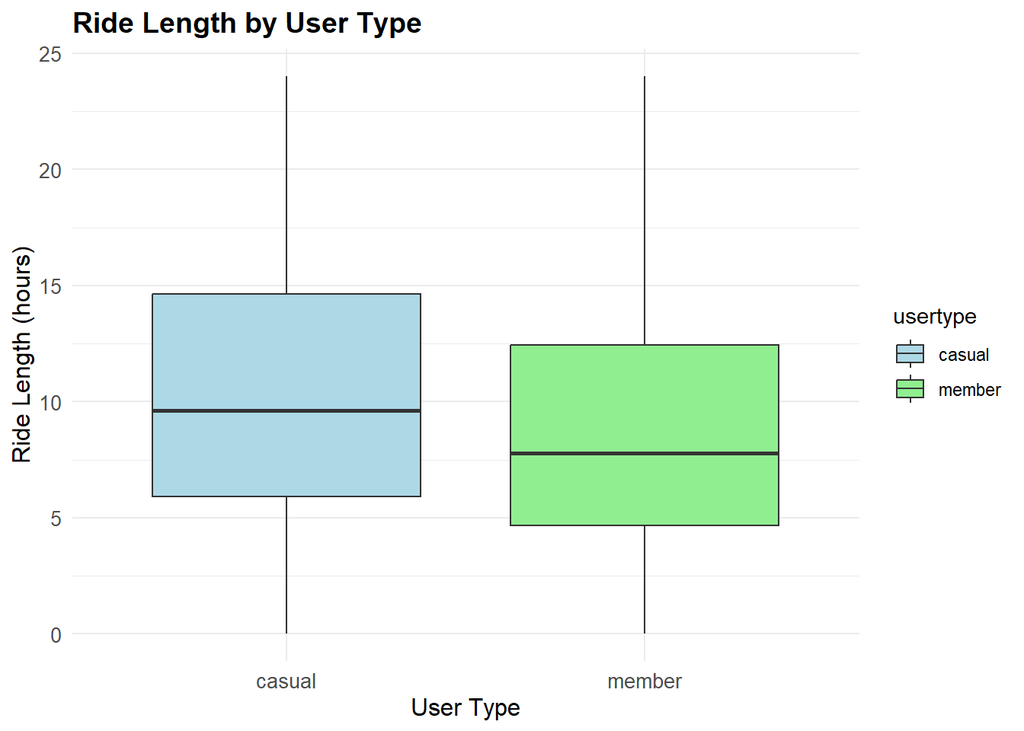

```r
ggplot(all_trips_v2, aes(x = usertype, y = ride_length, fill = usertype)) +
  geom_boxplot() +
  labs(
    x = "User Type",
    y = "Ride Length (hours)",
    title = "Ride Length by User Type"
  ) +
  scale_fill_manual(values = c("lightblue", "lightgreen")) +
  theme_minimal() +
  theme(
    axis.title.x = element_text(size = 12),
    axis.title.y = element_text(size = 12),
    axis.text = element_text(size = 10),
    plot.title = element_text(size = 14, face = "bold")
  )
```

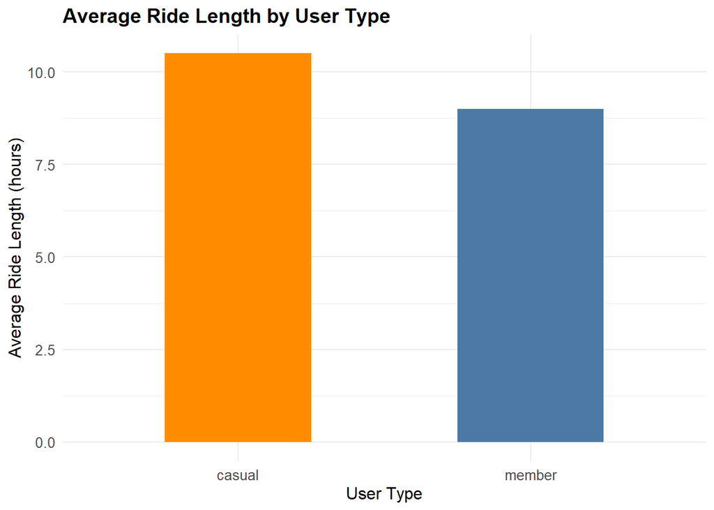

```r
# Calculate the average ride length by user type
avg_ride_length <- all_trips_v2 %>%
  group_by(usertype) %>%
  summarise(avg_ride_length = mean(ride_length, na.rm = TRUE))

# Create a bar plot with custom color palette
ggplot(avg_ride_length, aes(x = usertype, y = avg_ride_length, fill = usertype)) +
  geom_bar(stat = "identity", width = 0.5) +
  labs(
    x = "User Type",
    y = "Average Ride Length (hours)",
    title = "Average Ride Length by User Type"
  ) +
  scale_fill_manual(values = c("#FF8C00", "#4C79A6")) +
  theme_minimal() +
  theme(
    legend.position = "none",
    axis.title.x = element_text(size = 12),
    axis.title.y = element_text(size = 12),
    axis.text = element_text(size = 10),
    plot.title = element_text(size = 14, face = "bold")
  )
```

Determine the day and hour that reflect the highest usage in the Divvy bike data, you can analyze the data based on the number of rides by day of the week and hour of the day.

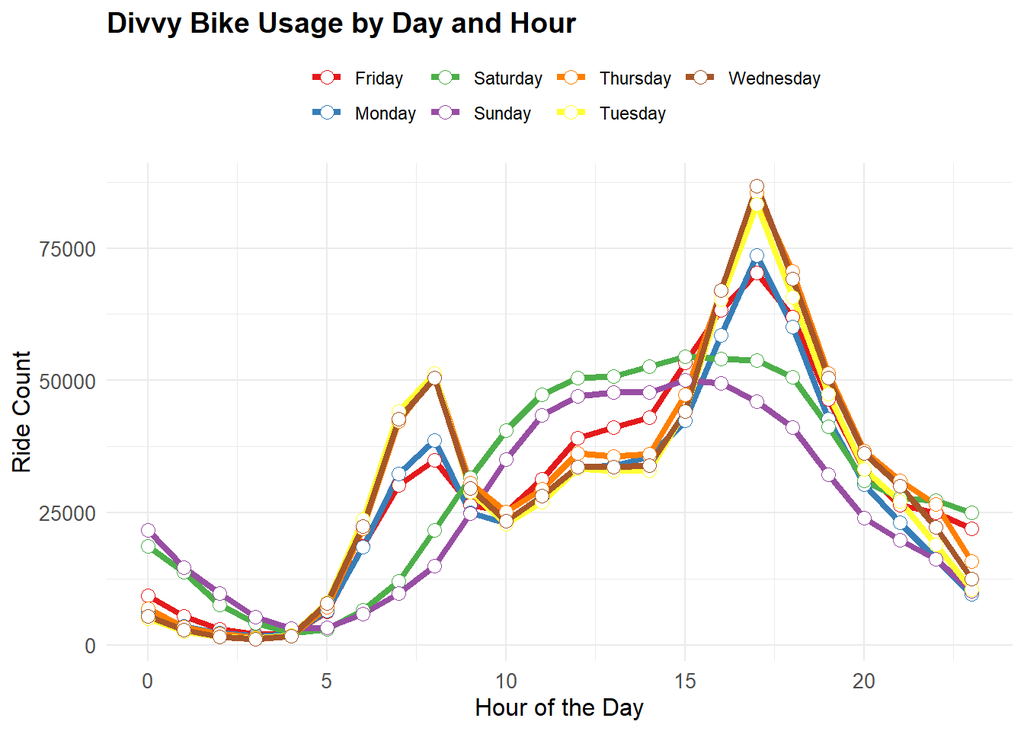

```r
# Calculate the number of rides by day of the week and hour of the day
usage_by_day_hour <- all_trips_v2 %>%
  group_by(day_of_week, hour = hour(start_time)) %>%
  summarise(ride_count = n(), .groups = "drop") %>%
  arrange(day_of_week, hour)

# Find the day and hour with the highest usage
max_usage <- usage_by_day_hour %>%
  filter(ride_count == max(ride_count))

# Plot the number of rides by day of the week and hour of the day
ggplot(usage_by_day_hour, aes(x = hour, y = ride_count, group = day_of_week, color = day_of_week)) +
  geom_line(size = 1.5) +
  geom_point(size = 3, shape = 21, fill = "white") +
  scale_color_brewer(palette = "Set1") +
  labs(
    x = "Hour of the Day",
    y = "Ride Count",
    title = "Divvy Bike Usage by Day and Hour"
  ) +
  theme_minimal() +
  theme(
    legend.position = "top",
    legend.title = element_blank(),
    axis.title.x = element_text(size = 12),
    axis.title.y = element_text(size = 12),
    axis.text = element_text(size = 10),
    plot.title = element_text(size = 14, face = "bold")
  )
```

```r
#cat("Day with the highest usage:", max_usage$day_of_week, "\n")
#cat("Hour with the highest usage:", max_usage$hour, "\n")
# Day with the highest usage: Wednesday
# Hour with the highest usage: 5  pm
```

This plot provides an overview of the bike usage patterns throughout the week, segmented by the hour of the day. The lines for each day represent the number of rides taken during each hour, allowing us to observe the peaks and troughs of usage.

The data suggests that bike usage patterns change significantly depending on the day of the week and the hour of the day. Some hours show consistently high bike usage across all days of the week, while others show variable usage.

However, it would be beneficial to look at the data more granularly to understand if this pattern holds across all days, or if there are specific days where the usage at 5 pm is particularly high. This information could be used to manage the bike fleet more effectively and ensure high availability during peak usage times.

```r
library(scales)
```

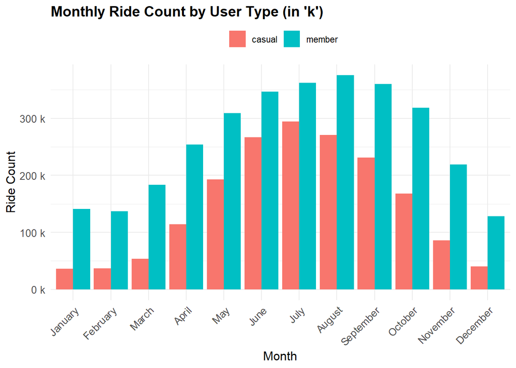

```r
# Define a vector of month names
month_names <- c("January", "February", "March", "April", "May", "June", "July", "August", "September", "October", "November", "December")

ride_count_by_month_user <- all_trips_v2 %>%
  drop_na(month, usertype) %>%
  group_by(month, usertype) %>%
  summarise(ride_count = n(), .groups = "drop")

# Convert month from numeric to factor with specified levels and labels
ride_count_by_month_user$month <- factor(ride_count_by_month_user$month, levels = 1:12, labels = month_names)
# Convert ride count to thousands
ride_count_by_month_user$ride_count <- ride_count_by_month_user$ride_count / 1000

ggplot(ride_count_by_month_user, aes(x = month, y = ride_count, fill = usertype)) +
  geom_bar(stat = "identity", position = "dodge") +
  labs(
    x = "Month",
    y = "Ride Count",
    fill = "User Type",
    title = "Monthly Ride Count by User Type (in 'k')"
  ) +
  scale_y_continuous(labels = function(x) paste(x, "k"))+
  theme_minimal() +
  theme(
    legend.position = "top",
    legend.title = element_blank(),
    axis.text.x = element_text(angle = 45, hjust = 1),
    axis.title.x = element_text(size = 12),
    axis.title.y = element_text(size = 12),
    axis.text = element_text(size = 10),
    plot.title = element_text(size = 14, face = "bold")
  )
```

The bar chart presents the ride count per month, divided by user type, for both casual and member riders. The ride count is plotted on the y-axis, while the x-axis represents each month of the year. This data visualization allows us to examine and compare the monthly ride patterns between the two types of users.

We observed that member rides outnumber casual rides every month. This suggests that members use the service more consistently throughout the year. For both user types, ride counts tend to increase from January to July, peak in the summer months (June, July, and August), and then gradually decrease towards the end of the year. Ride Length Analysis

Calculate the ride count by date

```r
# Calculate the ride count by month and year
ride_count_by_month_year <- all_trips_v2 %>%
  drop_na(date) %>%
  mutate(year_month = format(date, "%Y-%m")) %>%
  group_by(year_month) %>%
  summarise(ride_count = n()) %>%
  ungroup()

# Convert ride count to thousands
ride_count_by_month_year$ride_count <- ride_count_by_month_year$ride_count / 1000

# Find the highest and lowest ride count
max_ride_count <- max(ride_count_by_month_year$ride_count)
min_ride_count <- min(ride_count_by_month_year$ride_count)

# Find the month/year with the highest and lowest ride count
highest_month_year <- ride_count_by_month_year %>%
  filter(ride_count == max_ride_count) %>%
  pull(year_month)
lowest_month_year <- ride_count_by_month_year %>%
  filter(ride_count == min_ride_count) %>%
  pull(year_month)

# Print the highest and lowest ride month/year
cat("Highest bike ride month/year: ", highest_month_year, "\n")
```

```
## Highest bike ride month/year:  2022-07
```

```r
cat("Lowest bike ride month/year: ", lowest_month_year, "\n")
```

```
## Lowest bike ride month/year:  2022-12
```

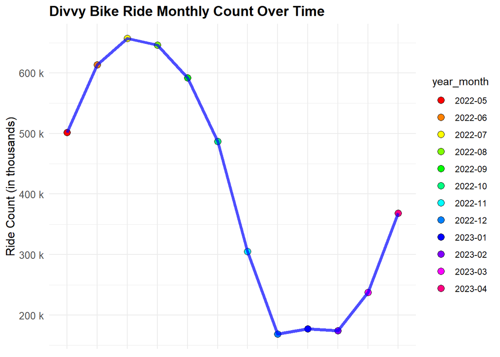

```r
# Create a line plot with smoothed line and filled points
ggplot(data = ride_count_by_month_year, aes(x = year_month, y = ride_count, group = 1)) +

  geom_point(aes(fill = year_month), size = 3, shape = 21, color = "black") +
  labs(
    x = NULL,
    y = "Ride Count (in thousands)",
    title = "Divvy Bike Ride Monthly Count Over Time"
  ) +
  geom_line(color = "blue", size = 1.5, alpha = 0.7) +
  scale_y_continuous(labels = function(x) paste(x, "k")) +
  scale_fill_manual(values = rainbow(length(unique(ride_count_by_month_year$year_month)))) +
  theme_minimal() +
  theme(
    axis.text.x = element_blank(),
    axis.title.x = element_blank(),
    axis.title.y = element_text(size = 12),
    axis.text = element_text(size = 10),
    plot.title = element_text(size = 14, face = "bold")
  )
```

The data indicates that in May 2022, there were approximately 502,000 rides, while in July 2022, the count rose to about 657,000 rides, which was the highest throughout the observed period. On the contrary, the lowest number of rides was in December 2022 with approximately 169,000 rides.

The data points in the plot are filled with different colors for each month, and the points are connected by a blue line to show the trend of ride count over time. The highest point on the plot corresponds to July 2022, which was the month with the highest ride count, while the lowest point corresponds to December 2022, the month with the lowest ride count.

From this visualization, one can infer the fluctuations in bike ride counts over the year. For example, the count tends to peak in summer (July) and drop in winter (December). These trends can be useful for understanding the seasonality of bike usage and planning accordingly.

```r
# write.csv(all_trips_v2, file = '~/github.io/data/cleaned_data.csv')
```